# BF528__FINAL_PROJECT_REPORT__Mohammad_Gharandouq

# Introduction

Dendritic cell (DC) progenitors undergo extensive transcriptional reprogramming during differentiation to generate distinct DC subsets, yet the contribution of chromatin accessibility to these transitions remains incompletely understood. In “The histone deacetylase HDAC1 controls dendritic cell development and anti-tumor immunity,” the authors demonstrate that HDAC1 plays a critical role in DC development by regulating epigenetic and transcriptional programs. Genetic deletion of HDAC1 selectively disrupts pDC and cDC2 differentiation, while cDC1 development remains largely unaffected.

Using ATAC-seq, the study shows that HDAC1 controls chromatin accessibility at key regulatory regions associated with transcription factors such as IRF4, IRF8, and SPIB, linking epigenetic regulation to DC lineage specification. These accessibility changes are accompanied by altered gene expression programs measured by RNA-seq, providing a mechanistic connection between chromatin state and transcriptional output.

In this project, we reproduce a subset of the original study’s ATAC-seq and RNA-seq analyses, focusing specifically on the cDC1 and cDC2 populations. Differential chromatin accessibility was assessed using ATAC-seq, while differential gene expression was evaluated by reanalyzing the authors’ raw RNA-seq data with DESeq2. By reproducing figures that integrate chromatin accessibility and gene expression changes in cDC1 and cDC2 cells, this analysis aims to evaluate how HDAC1-dependent chromatin remodeling contributes to subset-specific regulatory programs. The Fastq files of both ATAC-seq and RNA-seq were downloaded from the following GEO accession code (GSE266584). https://www.ncbi.nlm.nih.gov/geo/query/acc.cgi?acc=GSE266584

# Methodology

Raw single-end ATAC-seq FASTQ files were retrieved from public repositories using wget and processed using a fully reproducible workflow implemented in Nextflow v25.04.6.5954. All tools were run with default parameters unless otherwise specified. Initial quality assessment of raw single-end FASTQ files was performed using FastQC v0.12.1 to evaluate per-base sequence quality, GC content, and adapter contamination. Adapter trimming and quality filtering were conducted using Trimmomatic v0.39, removing Illumina adapter sequences and low-quality bases. A MultiQC v1.25 report was generated to aggregate quality control metrics, trimming statistics, and alignment summaries.

Trimmed reads were aligned to the mouse reference genome (GRCm39) using Bowtie2 v2.5.4, with genome indices built from the reference FASTA file. Aligned reads were converted to BAM format, filtered to remove mitochondrial reads, sorted by genomic coordinates, and indexed using SAMtools v1.21. Alignment statistics were generated using samtools flagstat to assess mapping efficiency. Genome-wide chromatin accessibility signal tracks were generated using deepTools v3.5.5 bamCoverage, producing normalized bigWig files. Sample-level correlation analysis was performed using deepTools multiBigwigSummary, followed by plotCorrelation to generate Spearman correlation heatmaps.

Accessible chromatin regions were identified using MACS3 v3.0.2, MACS3 peak calling was performed with model building disabled (–nomodel) and a fixed extension size to accommodate variable ATAC-seq fragment lengths. Peaks overlapping ENCODE blacklist regions were removed using BEDtools v2.31.1. ATAC-seq library quality was assessed by calculating the fraction of reads in peaks (FRiP) for each sample using BEDtools and SAMtools. Differential chromatin accessibility between wild-type and HDAC1 knockout samples was assessed separately for cDC1 and cDC2 subsets using DiffBind with the edgeR statistical framework. Differential peaks were classified as gained or lost accessibility in knockout samples based on fold-change direction and a significance threshold of p < 0.01 as reported in the original paper.

Chromatin accessibility patterns at differentially accessible regions were visualized by aggregating ATAC-seq signal around peak centers using deepTools computeMatrix in reference-point mode with ±1.5 kb flanking regions, followed by plotHeatmap and plotProfile. Transcription start site (TSS) enrichment was assessed as a quality control measure using deepTools computeMatrix centered on annotated TSSs with ±2 kb flanking regions and visualized using plotProfile.

RNA-sequencing data for cDC1 and cDC2 subsets were analyzed using DESeq2. Raw gene-level count matrices were filtered for low expression, and differential expression between wild-type and knockout conditions was assessed using a negative binomial model with Benjamini–Hochberg correction. Resulting RNA-seq log2 fold changes were integrated with gene-associated ATAC-seq accessibility changes to assess concordance between chromatin accessibility and transcriptional regulation.

# Sequencing quality control results

Quality control analysis of raw sequencing data indicated that all ATAC-seq libraries were of high quality. FastQC metrics summarized in the MultiQC report showed consistently high per-base sequence quality across all 8 samples, with mean Phred scores >30 across all base positions. Trimmomatic processing retained >95% of raw reads, with minimal adapter contamination detected. GC content was uniform across samples at approximately 47-49%, consistent with mammalian genomic DNA. Sequence duplication levels were moderately elevated as expected for ATAC-seq due to low input DNA and inherent PCR amplification. Per-sequence quality scores showed the majority of reads with mean quality >28, and no samples required exclusion based on raw sequencing quality.

# Alignment statistics

Alignment statistics from samtools flagstat revealed successful mapping across all samples. Samples showed high total read counts ranging from 22-34 million reads, with consistently low drop rates of 0.4-0.5%, indicating that the vast majority of reads aligned successfully to the reference genome. Duplicate rates ranged from 15-25%, which is acceptable for ATAC-seq given the low input DNA and necessary PCR amplification steps. After filtering for mitochondrial reads, 19.6-28.6 million high-quality reads per sample were retained for peak calling. These alignment metrics indicate robust library quality, sufficient sequencing depth for detecting accessible chromatin regions and identify differentially accessible peaks between conditions, while the comparable coverage across biological replicates ensures reliable differential accessibility testing. The combination of high-quality alignments and adequate sequencing depth supports robust peak calling and confident identification of condition-specific chromatin accessibility changes.

# Two ATAC-seq specific QC metrics

# 1. TSS enrichment score

TSS Enrichment Scores for ATAC-seq Samples

| Sample | TSS Enrichment | TSS Signal | Background Signal |
| --- | --- | --- | --- |
| cDC1_KO_1 | 13.57 | 24.86 | 1.83 |
| cDC1_KO_2 | 14.55 | 26.52 | 1.82 |
| cDC1_WT_1 | 15.48 | 32.37 | 2.09 |
| cDC1_WT_2 | 13.83 | 26.82 | 1.94 |
| cDC2_KO_1 | 12.16 | 18.90 | 1.55 |
| cDC2_KO_2 | 14.49 | 25.99 | 1.79 |
| cDC2_WT_1 | 13.50 | 27.79 | 2.06 |
| cDC2_WT_2 | 13.39 | 21.64 | 1.62 |

```
## Note: TSS Enrichment >10 indicates excellent quality ATAC-seq data
```

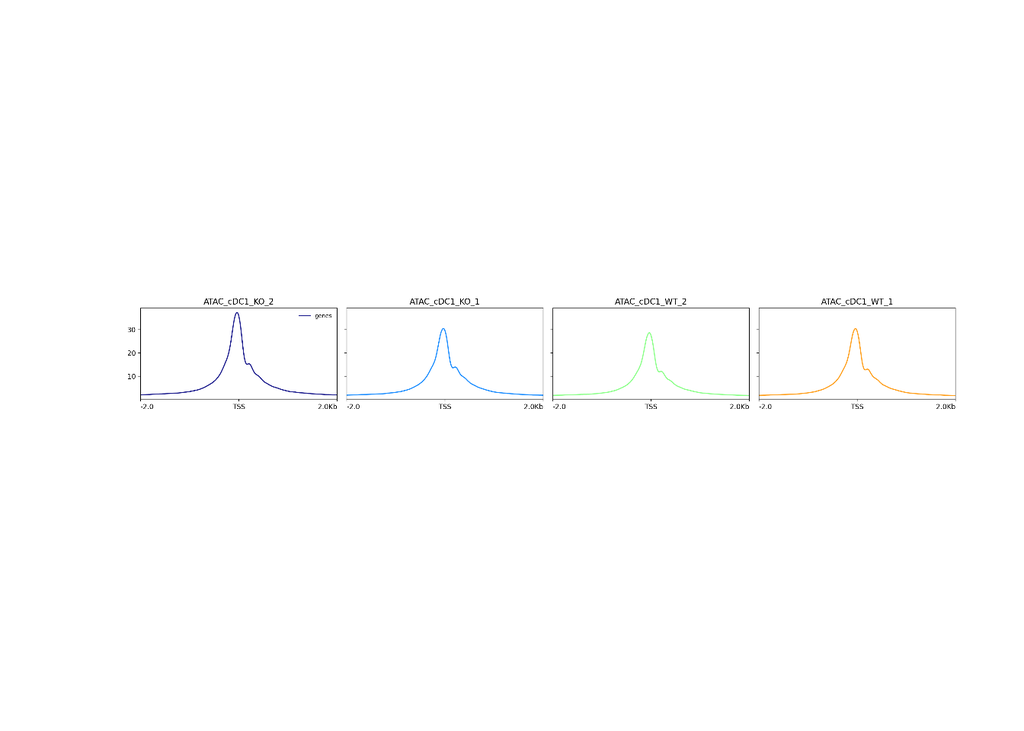

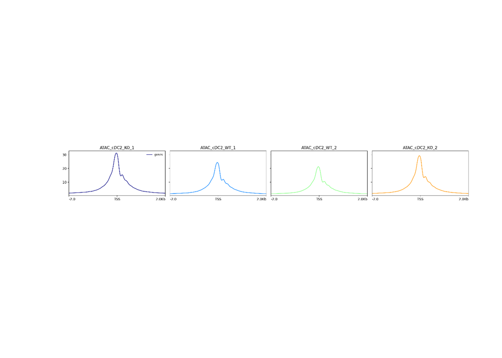

# 2. FRiP (Fraction of Reads in Peaks)

FRiP Quality Metrics for ATAC-seq Samples

| Sample | Total Reads (M) | Reads in Peaks (M) | FRiP (%) |
| --- | --- | --- | --- |
| ATAC_cDC1_KO_1 | 28.55 | 5.91 | 20.71 |
| ATAC_cDC1_KO_2 | 28.27 | 7.47 | 26.42 |
| ATAC_cDC1_WT_1 | 26.67 | 5.85 | 21.93 |
| ATAC_cDC1_WT_2 | 28.49 | 5.67 | 19.91 |
| ATAC_cDC2_KO_1 | 27.07 | 6.65 | 24.55 |
| ATAC_cDC2_KO_2 | 23.27 | 6.36 | 27.33 |
| ATAC_cDC2_WT_1 | 19.60 | 5.18 | 26.43 |
| ATAC_cDC2_WT_2 | 22.49 | 4.57 | 20.33 |

```
## Note: FRiP >20% indicates good quality ATAC-seq data
```

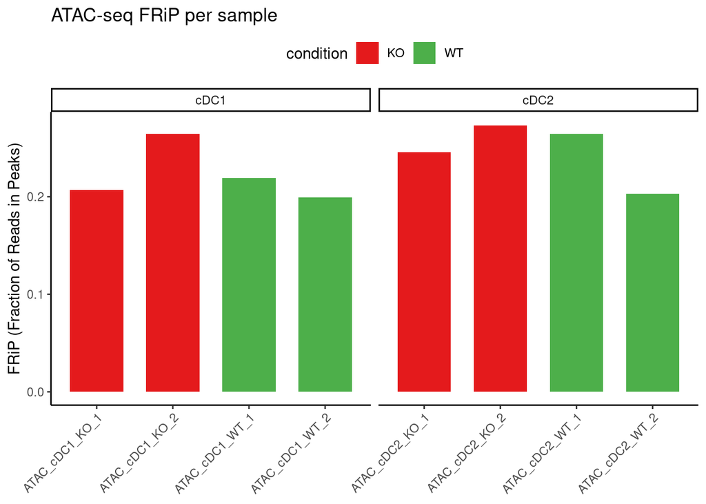

# Report how many differentially accessible regions your pipeline discovered in each of the two conditions.

Note: I have taken the values from Diffbind analyses results of cDC1 and cDC2.

Summary of Differentially Accessible Regions Identified by DiffBind

| Cell Type | Total DARs (p < 0.01) | Gained in KO | Lost in KO |
| --- | --- | --- | --- |
| cDC1 | 1680 | 1291 | 389 |
| cDC2 | 759 | 534 | 225 |

The differential accessibility analysis identified 1,680 significantly differentially accessible regions in cDC1 cells (p < 0.01), with 1,291 regions showing increased accessibility in the KO condition and 389 regions showing decreased accessibility in the KO condition.

In cDC2 cells, the analysis identified 759 significantly differentially accessible regions (p < 0.01), with 534 regions showing increased accessibility in the KO condition and 225 regions showing decreased accessibility in the KO condition.

While the absolute number of differentially accessible regions identified in this analysis is slightly lower than reported in the original study (1,680 vs. 1,863 DARs for cDC1 and 759 vs. 843 DARs for cDC2 at p < 0.01), the overall magnitude, directionality, and chromatin accessibility patterns are highly consistent. These minor differences are expected given independent reprocessing of raw sequencing data, differences in analysis parameters, and the use of a different reference genome build (mm39 in this study versus mm10 in the original publication).

# A figure showing the enrichment results of the differentially accessible regions:

```
## Number of genes cDC1: 1507
```

```
## Number of genes cDC2: 718
```

```
## Uploading data to Enrichr... Done.
##   Querying GO_Biological_Process_2025... Done.
##   Querying GO_Molecular_Function_2025... Done.
##   Querying KEGG_2021_Human... Done.
##   Querying WikiPathway_2024_Human... Done.
##   Querying Reactome_Pathways_2024... Done.
## Parsing results... Done.
```

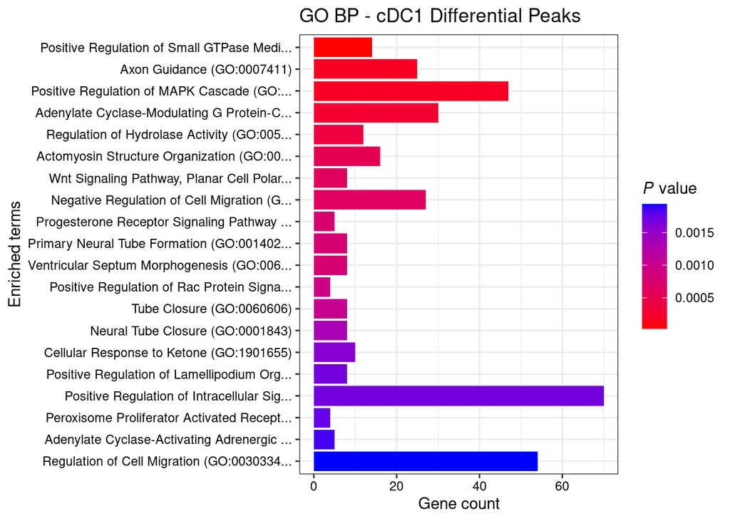

```
## Uploading data to Enrichr... Done.
##   Querying GO_Biological_Process_2025... Done.
##   Querying GO_Molecular_Function_2025... Done.
##   Querying KEGG_2021_Human... Done.
##   Querying WikiPathway_2024_Human... Done.
##   Querying Reactome_Pathways_2024... Done.
## Parsing results... Done.
```

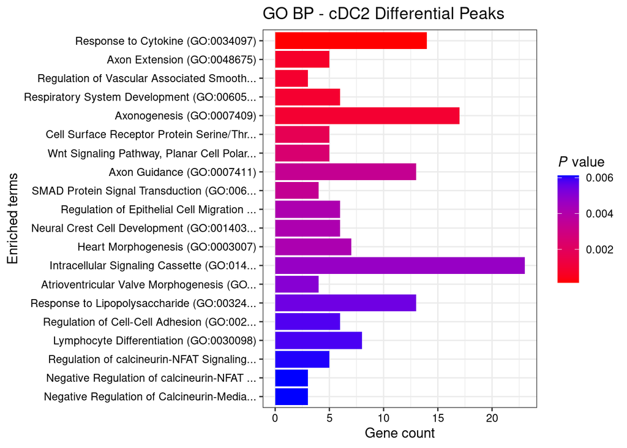

# A few sentences describing what the enrichment reveals.